# Introduction to Neural Networks: SVHN Digit Recognition

```python
from google.colab import drive
drive.mount('/content/drive')
```

## Problem Statement

### Context

The ability to process visual information using machine learning algorithms can be very useful as demonstrated in various applications. The Street View House Numbers (SVHN) dataset is one of the most popular ones. It has been used in neural networks created by Google to read house numbers and match them to their geolocations.

### Objective

To build a model that can identify house numbers in an image.

### Data Dictionary

- Number of classes: 10
- Training data: 42000 images
- Testing data: 18000 images

## Importing necessary libraries

```python
!pip install tensorflow==2.18.0 pandas==2.2.2 scikit-learn==1.3.2 numpy==1.26.2 matplotlib==3.8.0 seaborn==0.13.1 sklearn-pandas==2.2.0 -q --user
```

[output not shown]

Note: After running the above cell, kindly restart the notebook kernel and run all cells sequentially from the start again.

```python
# Libraries to help with reading and manipulating data
import pandas as pd
import numpy as np

# Library to split data
from sklearn.model_selection import train_test_split

# Library to encode the variables
from sklearn import preprocessing

# To plot confusion matrix
from sklearn.metrics import confusion_matrix, f1_score, accuracy_score, recall_score, precision_score

# libaries to help with data visualization
import matplotlib.pyplot as plt
import seaborn as sns

# library to import to standardize the data
from sklearn.preprocessing import StandardScaler

#To import different metrics
from sklearn import metrics

from tensorflow.keras import backend

# importing different functions to build models
from tensorflow.keras.models import Sequential
from tensorflow.keras.layers import Dense, Dropout, BatchNormalization
import tensorflow as tf
import random

# Importing Time
import time

#Importing classback API
from keras import callbacks
from keras.utils import to_categorical
from tensorflow.keras.optimizers import Adam
from tensorflow.keras import losses

# Library to avoid the warnings
import warnings
warnings.filterwarnings("ignore")
```

## Loading the dataset

```python
# Reading the dataset
X_test = pd.read_csv("/content/drive/MyDrive/AIML-UTAustin/Session Materials/M4-Neural Networks/W3-Project : SVHN Digit Recognition/X_test.csv")
X_train = pd.read_csv("/content/drive/MyDrive/AIML-UTAustin/Session Materials/M4-Neural Networks/W3-Project : SVHN Digit Recognition/X_train.csv")
y_test = pd.read_csv("/content/drive/MyDrive/AIML-UTAustin/Session Materials/M4-Neural Networks/W3-Project : SVHN Digit Recognition/y_test.csv")
y_train = pd.read_csv("/content/drive/MyDrive/AIML-UTAustin/Session Materials/M4-Neural Networks/W3-Project : SVHN Digit Recognition/y_train.csv")
```

```python
X_train.head()
```

|  | 0 | 1 | 2 | 3 | 4 | 5 | 6 | 7 | 8 | 9 | ... | 1014 | 1015 | 1016 | 1017 | 1018 | 1019 | 1020 | 1021 | 1022 | 1023 |
| --- | --- | --- | --- | --- | --- | --- | --- | --- | --- | --- | --- | --- | --- | --- | --- | --- | --- | --- | --- | --- | --- |
| 0 | 33.0704 | 30.2601 | 26.8520 | 25.8844 | 28.5421 | 33.1673 | 33.9069 | 31.2770 | 27.3313 | 23.9556 | ... | 37.5877 | 38.4736 | 41.1852 | 45.0816 | 46.0923 | 45.2172 | 47.2062 | 49.6682 | 50.8530 | 53.0377 |
| 1 | 86.9591 | 87.0685 | 88.3735 | 88.2272 | 87.0424 | 88.0746 | 89.0637 | 89.6399 | 87.6401 | 87.4121 | ... | 91.2313 | 90.5303 | 91.3992 | 92.6379 | 92.5409 | 89.9649 | 80.9103 | 75.2206 | 76.6396 | 79.2865 |
| 2 | 123.1250 | 125.8581 | 122.0757 | 116.0054 | 112.1629 | 110.7932 | 112.1351 | 112.8361 | 112.7221 | 112.7822 | ... | 69.8046 | 72.1033 | 73.9891 | 75.6469 | 76.0059 | 77.1368 | 84.0930 | 93.9349 | 104.7875 | 113.8252 |
| 3 | 147.6196 | 139.6204 | 142.6201 | 147.2175 | 151.9181 | 155.6188 | 157.6186 | 158.6185 | 159.1023 | 158.5153 | ... | 125.1057 | 133.1049 | 143.1039 | 151.7933 | 158.4398 | 157.8420 | 157.1302 | 157.1194 | 157.1795 | 157.1795 |
| 4 | 153.9890 | 155.1783 | 157.4276 | 157.2319 | 158.2919 | 161.0205 | 162.9880 | 163.9448 | 160.9451 | 156.9347 | ... | 112.6602 | 91.5529 | 72.6303 | 58.7565 | 45.3988 | 38.2747 | 40.5410 | 45.6930 | 48.6172 | 58.1494 |

5 rows × 1024 columns

```python
y_train.head()
```

|  | 0 |
| --- | --- |
| 0 | 2 |
| 1 | 6 |
| 2 | 7 |
| 3 | 4 |
| 4 | 4 |

```python
X_train.shape
```

```
(42000, 1024)
```

```python
X_test.shape
```

```
(18000, 1024)
```

```python
X_train.info()
```

```
<class 'pandas.core.frame.DataFrame'>
RangeIndex: 42000 entries, 0 to 41999
Columns: 1024 entries, 0 to 1023
dtypes: float64(1024)
memory usage: 328.1 MB
```

```python
X_test.info()
```

```
<class 'pandas.core.frame.DataFrame'>
RangeIndex: 18000 entries, 0 to 17999
Columns: 1024 entries, 0 to 1023
dtypes: float64(1024)
memory usage: 140.6 MB
```

```python
y_train.info()
```

```
<class 'pandas.core.frame.DataFrame'>
RangeIndex: 42000 entries, 0 to 41999
Data columns (total 1 columns):
 #   Column  Non-Null Count  Dtype
---  ------  --------------  -----
 0   0       42000 non-null  int64
dtypes: int64(1)
memory usage: 328.3 KB
```

```python
y_test.info()
```

```
<class 'pandas.core.frame.DataFrame'>
RangeIndex: 18000 entries, 0 to 17999
Data columns (total 1 columns):
 #   Column  Non-Null Count  Dtype
---  ------  --------------  -----
 0   0       18000 non-null  int64
dtypes: int64(1)
memory usage: 140.8 KB
```

```python
y_train["0"].value_counts(1)
```

| 0 | proportion |
| --- | --- |
| 3 | 0.101929 |
| 5 | 0.100762 |
| 2 | 0.099929 |
| 9 | 0.099905 |
| 7 | 0.099810 |
| 4 | 0.099714 |
| 8 | 0.099714 |
| 0 | 0.099667 |
| 1 | 0.099333 |
| 6 | 0.099238 |

**dtype:** float64

```python
y_test["0"].value_counts(1)
```

| 0 | proportion |
| --- | --- |
| 6 | 0.101778 |
| 1 | 0.101556 |
| 0 | 0.100778 |
| 8 | 0.100667 |
| 4 | 0.100667 |
| 7 | 0.100444 |
| 9 | 0.100222 |
| 2 | 0.100167 |
| 5 | 0.098222 |
| 3 | 0.095500 |

**dtype:** float64

## Normalize the data

```python
# normalize inputs from 0-255 to 0-1; to be used with the Neural Network
X_train = X_train / 255.0
X_test = X_test/255.0
```

```python
X_train.head()
```

|  | 0 | 1 | 2 | 3 | 4 | 5 | 6 | 7 | 8 | 9 | ... | 1014 | 1015 | 1016 | 1017 | 1018 | 1019 | 1020 | 1021 | 1022 | 1023 |
| --- | --- | --- | --- | --- | --- | --- | --- | --- | --- | --- | --- | --- | --- | --- | --- | --- | --- | --- | --- | --- | --- |
| 0 | 0.129688 | 0.118667 | 0.105302 | 0.101507 | 0.111930 | 0.130068 | 0.132968 | 0.122655 | 0.107182 | 0.093944 | ... | 0.147403 | 0.150877 | 0.161511 | 0.176791 | 0.180754 | 0.177322 | 0.185122 | 0.194777 | 0.199424 | 0.207991 |
| 1 | 0.341016 | 0.341445 | 0.346563 | 0.345989 | 0.341343 | 0.345391 | 0.349269 | 0.351529 | 0.343687 | 0.342793 | ... | 0.357770 | 0.355021 | 0.358428 | 0.363286 | 0.362905 | 0.352804 | 0.317295 | 0.294983 | 0.300547 | 0.310927 |
| 2 | 0.482843 | 0.493561 | 0.478728 | 0.454923 | 0.439855 | 0.434483 | 0.439745 | 0.442495 | 0.442047 | 0.442283 | ... | 0.273744 | 0.282758 | 0.290153 | 0.296655 | 0.298062 | 0.302497 | 0.329776 | 0.368372 | 0.410931 | 0.446373 |
| 3 | 0.578900 | 0.547531 | 0.559295 | 0.577324 | 0.595757 | 0.610270 | 0.618112 | 0.622033 | 0.623931 | 0.621629 | ... | 0.490611 | 0.521980 | 0.561192 | 0.595268 | 0.621333 | 0.618988 | 0.616197 | 0.616155 | 0.616390 | 0.616390 |
| 4 | 0.603878 | 0.608542 | 0.617363 | 0.616596 | 0.620753 | 0.631453 | 0.639169 | 0.642921 | 0.631157 | 0.615430 | ... | 0.441805 | 0.359031 | 0.284825 | 0.230418 | 0.178035 | 0.150097 | 0.158984 | 0.179188 | 0.190656 | 0.228037 |

5 rows × 1024 columns

## Encode the target variable

```python
# Encode the target variable
y_train_en = to_categorical(y_train)
y_test_en = to_categorical(y_test)
```

## Model Building: Neural Network

# **Utility Functions**

**Let's create a function for plotting loss and recall**

```python
def plot(history, name):
    """
    Function to plot loss/accuracy

    history: an object which stores the metrics and losses.
    name: can be one of Loss or Accuracy
    """
    fig, ax = plt.subplots() #Creating a subplot with figure and axes.
    plt.plot(history.history[name]) #Plotting the train accuracy or train loss
    plt.plot(history.history['val_'+name]) #Plotting the validation accuracy or validation loss

    plt.title('Model ' + name.capitalize()) #Defining the title of the plot.
    plt.ylabel(name.capitalize()) #Capitalizing the first letter.
    plt.xlabel('Epoch') #Defining the label for the x-axis.
    fig.legend(['Train', 'Validation'], loc="outside right upper") #Defining the legend, loc controls the position of the legend.
```

**Let's create a function for plotting the confusion matrix**

```python
def make_confusion_matrix(cf,
                          group_names=None,
                          categories='auto',
                          count=True,
                          percent=True,
                          cbar=True,
                          xyticks=True,
                          xyplotlabels=True,
                          sum_stats=True,
                          figsize=(20, 15),
                          cmap='Blues',
                          title=None):
    '''
    This function will make a pretty plot of an sklearn Confusion Matrix cm using a Seaborn heatmap visualization.
    Arguments
    '''


    # CODE TO GENERATE TEXT INSIDE EACH SQUARE
    blanks = ['' for i in range(cf.size)]

    if group_names and len(group_names)==cf.size:
        group_labels = ["{}\n".format(value) for value in group_names]
    else:
        group_labels = blanks

    if count:
        group_counts = ["{0:0.0f}\n".format(value) for value in cf.flatten()]
    else:
        group_counts = blanks

    if percent:
        group_percentages = ["{0:.2%}".format(value) for value in cf.flatten()/np.sum(cf)]
    else:
        group_percentages = blanks

    box_labels = [f"{v1}{v2}{v3}".strip() for v1, v2, v3 in zip(group_labels,group_counts,group_percentages)]
    box_labels = np.asarray(box_labels).reshape(cf.shape[0],cf.shape[1])


    # CODE TO GENERATE SUMMARY STATISTICS & TEXT FOR SUMMARY STATS
    if sum_stats:
        #Accuracy is sum of diagonal divided by total observations
        accuracy  = np.trace(cf) / float(np.sum(cf))

        #if it is a binary confusion matrix, show some more stats
        if len(cf)==2:
            #Metrics for Binary Confusion Matrices
            precision = cf[1,1] / sum(cf[:,1])
            recall    = cf[1,1] / sum(cf[1,:])
            f1_score  = 2*precision*recall / (precision + recall)
            stats_text = "\n\nAccuracy={:0.3f}\nPrecision={:0.3f}\nRecall={:0.3f}\nF1 Score={:0.3f}".format(
                accuracy,precision,recall,f1_score)
        else:
            stats_text = "\n\nAccuracy={:0.3f}".format(accuracy)
    else:
        stats_text = ""


    # SET FIGURE PARAMETERS ACCORDING TO OTHER ARGUMENTS
    if figsize==None:
        #Get default figure size if not set
        figsize = plt.rcParams.get('figure.figsize')

    if xyticks==False:
        #Do not show categories if xyticks is False
        categories=False


    # MAKE THE HEATMAP VISUALIZATION
    plt.figure(figsize=figsize)
    sns.heatmap(cf,annot=box_labels,fmt="",cmap=cmap,cbar=cbar,xticklabels=categories,yticklabels=categories)

    if xyplotlabels:
        plt.ylabel('True label')
        plt.xlabel('Predicted label' + stats_text)
    else:
        plt.xlabel(stats_text)

    if title:
        plt.title(title)
```

```python
# Function to clear backend and fixing seed for random number generators so that we can ensure we receive the same output everytime
def BackendClearSession():
    backend.clear_session()
    np.random.seed(42)
    random.seed(42)
    tf.random.set_seed(42)
```

```python
# Function to save recall score of train and test data of each model by name
def save_recall_score(model, model_name):
  # Predicting train data results
  y_train_pred = model.predict(X_train)

  # Predicting test data results
  y_test_pred = model.predict(X_test)

  # Convert predicted probabilities to class labels using argmax
  y_train_pred_argmax = np.argmax(y_train_pred, axis=1)
  y_test_pred_argmax = np.argmax(y_test_pred, axis=1)

  # Convert the one-hot encoded true labels to single class labels
  y_train_true_argmax = np.argmax(y_train_en, axis=1)
  y_test_true_argmax = np.argmax(y_test_en, axis=1)

  # Calculate recall score using the predicted class labels and the converted true labels
  train_metric_df.loc[model_name] = recall_score(y_train_true_argmax, y_train_pred_argmax, average='weighted')
  test_metric_df.loc[model_name] = recall_score(y_test_true_argmax, y_test_pred_argmax, average='weighted')
```

```python
# defining a function to compute different metrics to check performance of model built using statsmodels
def model_performance_classification(model, predictors, target):
    """
    Function to compute different metrics to check model performance

    model: classifier
    predictors: independent variables
    target: dependent variable
    """
    # Predicting target data with dependant variables
    y_pred = model.predict(predictors)

    # Convert predicted probabilities to class labels using argmax
    y_pred_argmax = np.argmax(y_pred, axis=1)

    # Convert the one-hot encoded true labels to single class labels
    target_argmax = np.argmax(target, axis=1)

    # Use the single class labels for calculating metrics
    acc = accuracy_score(target_argmax, y_pred_argmax)  # to compute Accuracy
    recall = recall_score(target_argmax, y_pred_argmax, average='weighted')  # to compute Recall
    precision = precision_score(target_argmax, y_pred_argmax, average='weighted')  # to compute Precision
    f1 = f1_score(target_argmax, y_pred_argmax, average='weighted')  # to compute F1-score

    # creating a dataframe of metrics
    df_perf = pd.DataFrame(
        {"Accuracy": acc, "Recall": recall, "Precision": precision, "F1 Score": f1,},
        index=[0],
    )

    return df_perf
```

**Let's create two blank dataframes that will store the recall values for all the models we build.**

```python
train_metric_df = pd.DataFrame(columns=["recall"])
test_metric_df = pd.DataFrame(columns=["recall"])
```

```python
BackendClearSession()
```

```python
model = Sequential()

# Input layer with 256 neurons with relu as activation function with input of 1024 variables
model.add(Dense(256, activation='relu',kernel_initializer='he_uniform',input_shape=(1024,)))

# Hidden layer with 64 neurons with relu as activation function
model.add(Dense(64, activation='relu',kernel_initializer='he_uniform'))

# Hidden layer with 64 neurons with relu as activation function
model.add(Dense(64, activation='relu',kernel_initializer='he_uniform'))

# Hidden layer with 64 neurons with relu as activation function
model.add(Dense(64, activation='relu',kernel_initializer='he_uniform'))

# Output layer with softmax as activation function with 10 neurons (We are predicting 10 classes)
model.add(Dense(10, activation='softmax'))

# Compile model
model.compile(optimizer='adam', loss='categorical_crossentropy', metrics=['accuracy', 'recall'])
```

```python
## Complete the code to obtain the summary of the model
model.summary()
```

```
Model: "sequential"
```

```
┏━━━━━━━━━━━━━━━━━━━━━━━━━━━━━━━━━┳━━━━━━━━━━━━━━━━━━━━━━━━┳━━━━━━━━━━━━━━━┓
┃ Layer (type)                    ┃ Output Shape           ┃       Param # ┃
┡━━━━━━━━━━━━━━━━━━━━━━━━━━━━━━━━━╇━━━━━━━━━━━━━━━━━━━━━━━━╇━━━━━━━━━━━━━━━┩
│ dense (Dense)                   │ (None, 256)            │       262,400 │
├─────────────────────────────────┼────────────────────────┼───────────────┤
│ dense_1 (Dense)                 │ (None, 64)             │        16,448 │
├─────────────────────────────────┼────────────────────────┼───────────────┤
│ dense_2 (Dense)                 │ (None, 64)             │         4,160 │
├─────────────────────────────────┼────────────────────────┼───────────────┤
│ dense_3 (Dense)                 │ (None, 64)             │         4,160 │
├─────────────────────────────────┼────────────────────────┼───────────────┤
│ dense_4 (Dense)                 │ (None, 10)             │           650 │
└─────────────────────────────────┴────────────────────────┴───────────────┘
```

```
 Total params: 287,818 (1.10 MB)
```

```
 Trainable params: 287,818 (1.10 MB)
```

```
 Non-trainable params: 0 (0.00 B)
```

```python
# defining batch size and # epochs upfront as we'll be using the same values for all models
epochs = 100
batch_size = 128
```

```python
## Fit  model on X_train and y_train_en data for 100 epochs
start = time.time()
history = model.fit(X_train, y_train_en, validation_split=0.2, epochs=epochs, batch_size=batch_size, verbose=2)
end = time.time()
```

```
263/263 - 6s - 23ms/step - accuracy: 0.1091 - loss: 2.3012 - recall: 0.0000e+00 - val_accuracy: 0.1302 - val_loss: 2.2619 - val_recall: 0.0000e+00
263/263 - 4s - 15ms/step - accuracy: 0.1862 - loss: 2.1254 - recall: 0.0017 - val_accuracy: 0.2732 - val_loss: 1.9631 - val_recall: 0.0142
263/263 - 3s - 10ms/step - accuracy: 0.3832 - loss: 1.7327 - recall: 0.1126 - val_accuracy: 0.4874 - val_loss: 1.4683 - val_recall: 0.2645
263/263 - 3s - 10ms/step - accuracy: 0.5146 - loss: 1.4316 - recall: 0.2880 - val_accuracy: 0.5490 - val_loss: 1.3390 - val_recall: 0.3633
263/263 - 3s - 11ms/step - accuracy: 0.5759 - loss: 1.2883 - recall: 0.3967 - val_accuracy: 0.5839 - val_loss: 1.2740 - val_recall: 0.4193
263/263 - 5s - 19ms/step - accuracy: 0.6135 - loss: 1.1981 - recall: 0.4579 - val_accuracy: 0.6370 - val_loss: 1.1432 - val_recall: 0.4848
263/263 - 5s - 17ms/step - accuracy: 0.6387 - loss: 1.1326 - recall: 0.5001 - val_accuracy: 0.6620 - val_loss: 1.0754 - val_recall: 0.5187
263/263 - 3s - 12ms/step - accuracy: 0.6589 - loss: 1.0806 - recall: 0.5312 - val_accuracy: 0.6702 - val_loss: 1.0540 - val_recall: 0.5456
263/263 - 4s - 14ms/step - accuracy: 0.6737 - loss: 1.0351 - recall: 0.5540 - val_accuracy: 0.6686 - val_loss: 1.0370 - val_recall: 0.5552
263/263 - 4s - 15ms/step - accuracy: 0.6878 - loss: 0.9917 - recall: 0.5755 - val_accuracy: 0.6796 - val_loss: 1.0072 - val_recall: 0.5711
263/263 - 5s - 19ms/step - accuracy: 0.7001 - loss: 0.9555 - recall: 0.5922 - val_accuracy: 0.6937 - val_loss: 0.9751 - val_recall: 0.5886
263/263 - 3s - 12ms/step - accuracy: 0.7065 - loss: 0.9246 - recall: 0.6043 - val_accuracy: 0.7061 - val_loss: 0.9399 - val_recall: 0.6077
263/263 - 4s - 14ms/step - accuracy: 0.7175 - loss: 0.8947 - recall: 0.6189 - val_accuracy: 0.7186 - val_loss: 0.9030 - val_recall: 0.6246
263/263 - 3s - 10ms/step - accuracy: 0.7294 - loss: 0.8622 - recall: 0.6341 - val_accuracy: 0.7231 - val_loss: 0.8855 - val_recall: 0.6389
263/263 - 3s - 10ms/step - accuracy: 0.7343 - loss: 0.8449 - recall: 0.6413 - val_accuracy: 0.7276 - val_loss: 0.8766 - val_recall: 0.6488
263/263 - 6s - 23ms/step - accuracy: 0.7384 - loss: 0.8287 - recall: 0.6475 - val_accuracy: 0.7298 - val_loss: 0.8710 - val_recall: 0.6521
263/263 - 3s - 13ms/step - accuracy: 0.7435 - loss: 0.8083 - recall: 0.6563 - val_accuracy: 0.7407 - val_loss: 0.8412 - val_recall: 0.6639
263/263 - 3s - 10ms/step - accuracy: 0.7494 - loss: 0.7943 - recall: 0.6611 - val_accuracy: 0.7350 - val_loss: 0.8511 - val_recall: 0.6544
263/263 - 5s - 20ms/step - accuracy: 0.7533 - loss: 0.7745 - recall: 0.6693 - val_accuracy: 0.7480 - val_loss: 0.8229 - val_recall: 0.6757
263/263 - 6s - 22ms/step - accuracy: 0.7603 - loss: 0.7558 - recall: 0.6776 - val_accuracy: 0.7485 - val_loss: 0.8163 - val_recall: 0.6767
263/263 - 5s - 17ms/step - accuracy: 0.7630 - loss: 0.7514 - recall: 0.6804 - val_accuracy: 0.7494 - val_loss: 0.8147 - val_recall: 0.6832
263/263 - 3s - 13ms/step - accuracy: 0.7649 - loss: 0.7421 - recall: 0.6826 - val_accuracy: 0.7518 - val_loss: 0.8083 - val_recall: 0.6813
263/263 - 5s - 20ms/step - accuracy: 0.7687 - loss: 0.7267 - recall: 0.6901 - val_accuracy: 0.7529 - val_loss: 0.8030 - val_recall: 0.6835
263/263 - 4s - 16ms/step - accuracy: 0.7749 - loss: 0.7131 - recall: 0.6965 - val_accuracy: 0.7511 - val_loss: 0.8099 - val_recall: 0.6814
263/263 - 6s - 21ms/step - accuracy: 0.7783 - loss: 0.7028 - recall: 0.6999 - val_accuracy: 0.7533 - val_loss: 0.8086 - val_recall: 0.6836
263/263 - 5s - 17ms/step - accuracy: 0.7783 - loss: 0.7004 - recall: 0.7037 - val_accuracy: 0.7582 - val_loss: 0.7897 - val_recall: 0.6920
263/263 - 5s - 19ms/step - accuracy: 0.7815 - loss: 0.6857 - recall: 0.7082 - val_accuracy: 0.7520 - val_loss: 0.8097 - val_recall: 0.6896
263/263 - 3s - 12ms/step - accuracy: 0.7837 - loss: 0.6826 - recall: 0.7085 - val_accuracy: 0.7504 - val_loss: 0.8122 - val_recall: 0.6845
263/263 - 4s - 15ms/step - accuracy: 0.7818 - loss: 0.6840 - recall: 0.7098 - val_accuracy: 0.7590 - val_loss: 0.7939 - val_recall: 0.6956
263/263 - 3s - 10ms/step - accuracy: 0.7873 - loss: 0.6681 - recall: 0.7164 - val_accuracy: 0.7712 - val_loss: 0.7577 - val_recall: 0.7074
263/263 - 3s - 10ms/step - accuracy: 0.7933 - loss: 0.6554 - recall: 0.7229 - val_accuracy: 0.7694 - val_loss: 0.7665 - val_recall: 0.7131
263/263 - 3s - 10ms/step - accuracy: 0.7928 - loss: 0.6529 - recall: 0.7241 - val_accuracy: 0.7636 - val_loss: 0.7732 - val_recall: 0.7069
263/263 - 6s - 23ms/step - accuracy: 0.7950 - loss: 0.6479 - recall: 0.7258 - val_accuracy: 0.7618 - val_loss: 0.7774 - val_recall: 0.7083
263/263 - 5s - 21ms/step - accuracy: 0.7970 - loss: 0.6371 - recall: 0.7307 - val_accuracy: 0.7629 - val_loss: 0.7857 - val_recall: 0.7077
263/263 - 5s - 17ms/step - accuracy: 0.7981 - loss: 0.6331 - recall: 0.7326 - val_accuracy: 0.7636 - val_loss: 0.7878 - val_recall: 0.7139
263/263 - 4s - 17ms/step - accuracy: 0.7985 - loss: 0.6341 - recall: 0.7325 - val_accuracy: 0.7592 - val_loss: 0.8052 - val_recall: 0.7086
263/263 - 3s - 13ms/step - accuracy: 0.8010 - loss: 0.6250 - recall: 0.7359 - val_accuracy: 0.7573 - val_loss: 0.8097 - val_recall: 0.7063
263/263 - 5s - 19ms/step - accuracy: 0.7977 - loss: 0.6331 - recall: 0.7319 - val_accuracy: 0.7415 - val_loss: 0.8627 - val_recall: 0.6869
263/263 - 6s - 22ms/step - accuracy: 0.8005 - loss: 0.6211 - recall: 0.7369 - val_accuracy: 0.7460 - val_loss: 0.8448 - val_recall: 0.6971
263/263 - 3s - 10ms/step - accuracy: 0.8020 - loss: 0.6174 - recall: 0.7413 - val_accuracy: 0.7444 - val_loss: 0.8535 - val_recall: 0.6917
```

[output cut: 45 more lines]

```
263/263 - 6s - 24ms/step - accuracy: 0.8508 - loss: 0.4600 - recall: 0.8062 - val_accuracy: 0.7661 - val_loss: 0.8822 - val_recall: 0.7308
263/263 - 4s - 14ms/step - accuracy: 0.8492 - loss: 0.4599 - recall: 0.8064 - val_accuracy: 0.7613 - val_loss: 0.8876 - val_recall: 0.7204
263/263 - 5s - 19ms/step - accuracy: 0.8497 - loss: 0.4542 - recall: 0.8076 - val_accuracy: 0.7629 - val_loss: 0.9056 - val_recall: 0.7313
263/263 - 4s - 15ms/step - accuracy: 0.8537 - loss: 0.4470 - recall: 0.8113 - val_accuracy: 0.7607 - val_loss: 0.9210 - val_recall: 0.7280
263/263 - 4s - 14ms/step - accuracy: 0.8501 - loss: 0.4542 - recall: 0.8087 - val_accuracy: 0.7642 - val_loss: 0.8989 - val_recall: 0.7296
263/263 - 3s - 10ms/step - accuracy: 0.8485 - loss: 0.4586 - recall: 0.8077 - val_accuracy: 0.7680 - val_loss: 0.8752 - val_recall: 0.7344
263/263 - 6s - 22ms/step - accuracy: 0.8513 - loss: 0.4479 - recall: 0.8116 - val_accuracy: 0.7718 - val_loss: 0.8717 - val_recall: 0.7377
263/263 - 4s - 13ms/step - accuracy: 0.8530 - loss: 0.4465 - recall: 0.8121 - val_accuracy: 0.7719 - val_loss: 0.8705 - val_recall: 0.7436
263/263 - 3s - 10ms/step - accuracy: 0.8550 - loss: 0.4400 - recall: 0.8148 - val_accuracy: 0.7693 - val_loss: 0.8896 - val_recall: 0.7340
263/263 - 5s - 19ms/step - accuracy: 0.8593 - loss: 0.4269 - recall: 0.8205 - val_accuracy: 0.7718 - val_loss: 0.8788 - val_recall: 0.7426
263/263 - 4s - 14ms/step - accuracy: 0.8545 - loss: 0.4393 - recall: 0.8158 - val_accuracy: 0.7673 - val_loss: 0.8791 - val_recall: 0.7357
263/263 - 5s - 18ms/step - accuracy: 0.8548 - loss: 0.4366 - recall: 0.8152 - val_accuracy: 0.7668 - val_loss: 0.9041 - val_recall: 0.7305
263/263 - 5s - 19ms/step - accuracy: 0.8546 - loss: 0.4390 - recall: 0.8150 - val_accuracy: 0.7748 - val_loss: 0.8701 - val_recall: 0.7405
263/263 - 4s - 15ms/step - accuracy: 0.8552 - loss: 0.4424 - recall: 0.8137 - val_accuracy: 0.7688 - val_loss: 0.8889 - val_recall: 0.7345
263/263 - 4s - 15ms/step - accuracy: 0.8557 - loss: 0.4367 - recall: 0.8149 - val_accuracy: 0.7730 - val_loss: 0.8517 - val_recall: 0.7408
```

```python
print("Time taken in seconds ",end-start)
```

```
Time taken in seconds  411.1227877140045
```

**Loss function**

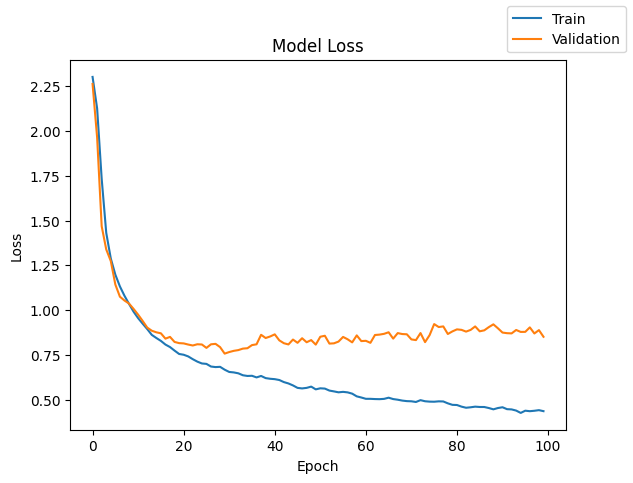

```python
plot(history,'loss')
```

**Recall**

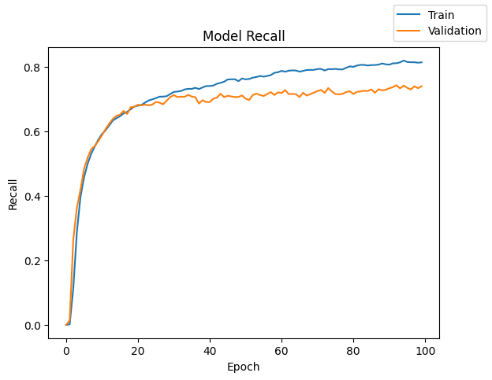

```python
plot(history,'recall')
```

```python
model_train_perf = model_performance_classification(model, X_train, y_train_en)
model_train_perf
```

```
1313/1313 ━━━━━━━━━━━━━━━━━━━━ 3s 2ms/step
```

|  | Accuracy | Recall | Precision | F1 Score |
| --- | --- | --- | --- | --- |
| 0 | 0.829929 | 0.829929 | 0.83323 | 0.830265 |

```python
model_test_perf = model_performance_classification(model, X_test, y_test_en)
model_test_perf
```

```
563/563 ━━━━━━━━━━━━━━━━━━━━ 1s 2ms/step
```

|  | Accuracy | Recall | Precision | F1 Score |
| --- | --- | --- | --- | --- |
| 0 | 0.775611 | 0.775611 | 0.7788 | 0.775934 |

```python
save_recall_score(model, "NN with Adam and He initialization")
```

```
1313/1313 ━━━━━━━━━━━━━━━━━━━━ 3s 2ms/step
563/563 ━━━━━━━━━━━━━━━━━━━━ 1s 2ms/step
```

**Classification Report**

```python
## Predict Model on X_train
y_pred = model.predict(X_train)

## Predict y_pred using argmax
y_pred_argmax = np.argmax(y_pred, axis=1)

# Convert y_train_en back to multiclass format (single integer labels)
y_train_true_argmax = np.argmax(y_train_en, axis=1)

## Classification report for train data
cr = metrics.classification_report(y_train_true_argmax, y_pred_argmax)
print(cr)
```

```
1313/1313 ━━━━━━━━━━━━━━━━━━━━ 3s 2ms/step
              precision    recall  f1-score   support

           0       0.78      0.91      0.84      4186
           1       0.85      0.83      0.84      4172
           2       0.84      0.86      0.85      4197
           3       0.85      0.78      0.81      4281
           4       0.91      0.81      0.86      4188
           5       0.77      0.84      0.80      4232
           6       0.82      0.82      0.82      4168
           7       0.89      0.84      0.86      4192
           8       0.77      0.81      0.79      4188
           9       0.85      0.81      0.83      4196

    accuracy                           0.83     42000
   macro avg       0.83      0.83      0.83     42000
weighted avg       0.83      0.83      0.83     42000
```

```python
## Predict Model on X_test
y_pred = model.predict(X_test)

## Predict y_pred using argmax
y_pred_argmax = np.argmax(y_pred, axis=1)

# Convert y_train_en back to multiclass format (single integer labels)
y_test_true_argmax = np.argmax(y_test_en, axis=1)

## Classification report for train data
cr = metrics.classification_report(y_test_true_argmax, y_pred_argmax)
print(cr)
```

```
563/563 ━━━━━━━━━━━━━━━━━━━━ 2s 3ms/step
              precision    recall  f1-score   support

           0       0.74      0.87      0.80      1814
           1       0.82      0.78      0.80      1828
           2       0.79      0.80      0.80      1803
           3       0.76      0.71      0.73      1719
           4       0.86      0.77      0.81      1812
           5       0.70      0.78      0.73      1768
           6       0.76      0.77      0.76      1832
           7       0.85      0.79      0.82      1808
           8       0.72      0.73      0.73      1812
           9       0.79      0.74      0.77      1804

    accuracy                           0.78     18000
   macro avg       0.78      0.78      0.78     18000
weighted avg       0.78      0.78      0.78     18000
```

**Confusion Matrix**

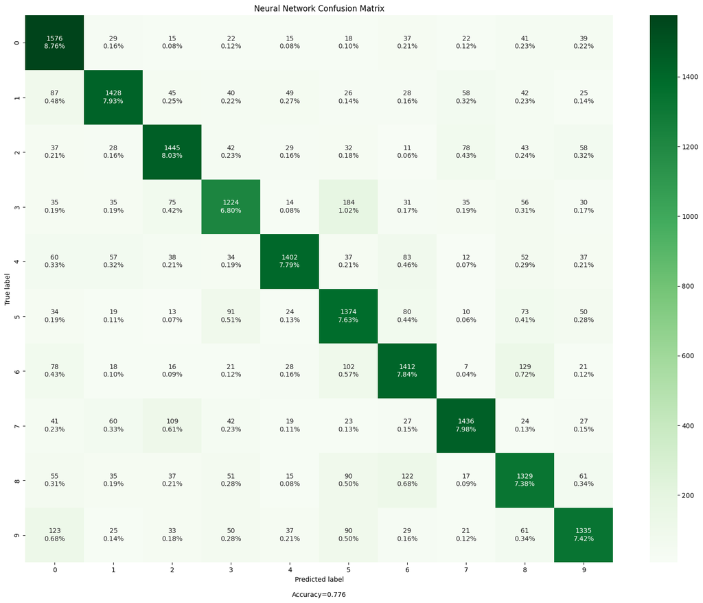

```python
## Plot Confusion Matrix
# Convert y_test_en back to multiclass format (single integer labels)
y_test_true_argmax = np.argmax(y_test_en, axis=1)

cm = confusion_matrix(y_test_true_argmax, y_pred_argmax)
make_confusion_matrix(cm, cmap='Greens', title='Neural Network Confusion Matrix')
plt.show()
```

## Model Improvement: Neural Network model with Adam Optimizer

```python
BackendClearSession()
```

```python
## Initializing Neural Network
model_2 = Sequential()

## Add input layer with 64 neurons and relu as activation function
model_2.add(Dense(64, activation='relu', input_dim = X_train.shape[1]))

## First hidden layer with 32 neurons with relu as activation functions
model_2.add(Dense(32, activation='relu'))

## Add the output layer with softmax as activation function with 10 neurons (We are predicting 10 classes)
model_2.add(Dense(10, activation = 'softmax'))

# Adam Optimizer
optimizer = tf.keras.optimizers.Adam(0.001)

## Compile Model with binary cross entropy as loss function and accuracy as metrics
model_2.compile(loss='categorical_crossentropy', optimizer=optimizer, metrics=['accuracy', 'recall'])
```

```python
## Get Model summary
model_2.summary()
```

```
Model: "sequential"
```

```
┏━━━━━━━━━━━━━━━━━━━━━━━━━━━━━━━━━┳━━━━━━━━━━━━━━━━━━━━━━━━┳━━━━━━━━━━━━━━━┓
┃ Layer (type)                    ┃ Output Shape           ┃       Param # ┃
┡━━━━━━━━━━━━━━━━━━━━━━━━━━━━━━━━━╇━━━━━━━━━━━━━━━━━━━━━━━━╇━━━━━━━━━━━━━━━┩
│ dense (Dense)                   │ (None, 64)             │        65,600 │
├─────────────────────────────────┼────────────────────────┼───────────────┤
│ dense_1 (Dense)                 │ (None, 32)             │         2,080 │
├─────────────────────────────────┼────────────────────────┼───────────────┤
│ dense_2 (Dense)                 │ (None, 10)             │           330 │
└─────────────────────────────────┴────────────────────────┴───────────────┘
```

```
 Total params: 68,010 (265.66 KB)
```

```
 Trainable params: 68,010 (265.66 KB)
```

```
 Non-trainable params: 0 (0.00 B)
```

```python
## Fit the model on X_train and y_train_en data for 100 epochs
start = time.time()
history_2 = model_2.fit(X_train, y_train_en, validation_split=0.2, epochs=epochs, batch_size=batch_size, verbose=2)
end = time.time()
```

```
263/263 - 3s - 12ms/step - accuracy: 0.1159 - loss: 2.3002 - recall: 0.0000e+00 - val_accuracy: 0.1632 - val_loss: 2.2677 - val_recall: 0.0000e+00
263/263 - 2s - 9ms/step - accuracy: 0.2057 - loss: 2.1620 - recall: 0.0107 - val_accuracy: 0.2912 - val_loss: 2.0361 - val_recall: 0.0356
263/263 - 2s - 9ms/step - accuracy: 0.3795 - loss: 1.8278 - recall: 0.0651 - val_accuracy: 0.4399 - val_loss: 1.6524 - val_recall: 0.1249
263/263 - 3s - 12ms/step - accuracy: 0.4791 - loss: 1.5711 - recall: 0.1579 - val_accuracy: 0.5188 - val_loss: 1.4720 - val_recall: 0.2129
263/263 - 2s - 8ms/step - accuracy: 0.5277 - loss: 1.4524 - recall: 0.2320 - val_accuracy: 0.5356 - val_loss: 1.4139 - val_recall: 0.2737
263/263 - 2s - 8ms/step - accuracy: 0.5579 - loss: 1.3771 - recall: 0.2928 - val_accuracy: 0.5636 - val_loss: 1.3561 - val_recall: 0.3224
263/263 - 3s - 10ms/step - accuracy: 0.5815 - loss: 1.3222 - recall: 0.3419 - val_accuracy: 0.5856 - val_loss: 1.3047 - val_recall: 0.3599
263/263 - 3s - 10ms/step - accuracy: 0.5976 - loss: 1.2806 - recall: 0.3788 - val_accuracy: 0.6010 - val_loss: 1.2642 - val_recall: 0.3949
263/263 - 1s - 6ms/step - accuracy: 0.6108 - loss: 1.2454 - recall: 0.4077 - val_accuracy: 0.6168 - val_loss: 1.2301 - val_recall: 0.4243
263/263 - 2s - 8ms/step - accuracy: 0.6193 - loss: 1.2189 - recall: 0.4320 - val_accuracy: 0.6254 - val_loss: 1.2031 - val_recall: 0.4432
263/263 - 2s - 8ms/step - accuracy: 0.6259 - loss: 1.1977 - recall: 0.4487 - val_accuracy: 0.6306 - val_loss: 1.1850 - val_recall: 0.4606
263/263 - 2s - 7ms/step - accuracy: 0.6340 - loss: 1.1792 - recall: 0.4625 - val_accuracy: 0.6365 - val_loss: 1.1710 - val_recall: 0.4702
263/263 - 1s - 5ms/step - accuracy: 0.6388 - loss: 1.1652 - recall: 0.4735 - val_accuracy: 0.6368 - val_loss: 1.1596 - val_recall: 0.4792
263/263 - 2s - 9ms/step - accuracy: 0.6426 - loss: 1.1542 - recall: 0.4815 - val_accuracy: 0.6404 - val_loss: 1.1501 - val_recall: 0.4850
263/263 - 3s - 10ms/step - accuracy: 0.6469 - loss: 1.1435 - recall: 0.4893 - val_accuracy: 0.6451 - val_loss: 1.1410 - val_recall: 0.4907
263/263 - 3s - 12ms/step - accuracy: 0.6499 - loss: 1.1338 - recall: 0.4951 - val_accuracy: 0.6506 - val_loss: 1.1274 - val_recall: 0.4987
263/263 - 2s - 8ms/step - accuracy: 0.6537 - loss: 1.1219 - recall: 0.5033 - val_accuracy: 0.6550 - val_loss: 1.1156 - val_recall: 0.5049
263/263 - 1s - 5ms/step - accuracy: 0.6571 - loss: 1.1122 - recall: 0.5100 - val_accuracy: 0.6570 - val_loss: 1.1085 - val_recall: 0.5107
263/263 - 3s - 10ms/step - accuracy: 0.6594 - loss: 1.1046 - recall: 0.5146 - val_accuracy: 0.6590 - val_loss: 1.1018 - val_recall: 0.5146
263/263 - 3s - 10ms/step - accuracy: 0.6631 - loss: 1.0961 - recall: 0.5196 - val_accuracy: 0.6598 - val_loss: 1.0957 - val_recall: 0.5173
263/263 - 1s - 5ms/step - accuracy: 0.6655 - loss: 1.0889 - recall: 0.5244 - val_accuracy: 0.6608 - val_loss: 1.0904 - val_recall: 0.5205
263/263 - 1s - 5ms/step - accuracy: 0.6679 - loss: 1.0809 - recall: 0.5290 - val_accuracy: 0.6623 - val_loss: 1.0859 - val_recall: 0.5235
263/263 - 2s - 7ms/step - accuracy: 0.6723 - loss: 1.0723 - recall: 0.5338 - val_accuracy: 0.6649 - val_loss: 1.0808 - val_recall: 0.5242
263/263 - 2s - 9ms/step - accuracy: 0.6752 - loss: 1.0653 - recall: 0.5388 - val_accuracy: 0.6681 - val_loss: 1.0729 - val_recall: 0.5270
263/263 - 1s - 6ms/step - accuracy: 0.6769 - loss: 1.0600 - recall: 0.5426 - val_accuracy: 0.6706 - val_loss: 1.0667 - val_recall: 0.5336
263/263 - 3s - 10ms/step - accuracy: 0.6785 - loss: 1.0535 - recall: 0.5472 - val_accuracy: 0.6743 - val_loss: 1.0602 - val_recall: 0.5383
263/263 - 1s - 5ms/step - accuracy: 0.6807 - loss: 1.0487 - recall: 0.5491 - val_accuracy: 0.6763 - val_loss: 1.0556 - val_recall: 0.5406
263/263 - 3s - 10ms/step - accuracy: 0.6819 - loss: 1.0432 - recall: 0.5515 - val_accuracy: 0.6780 - val_loss: 1.0518 - val_recall: 0.5430
263/263 - 1s - 5ms/step - accuracy: 0.6836 - loss: 1.0388 - recall: 0.5533 - val_accuracy: 0.6770 - val_loss: 1.0502 - val_recall: 0.5418
263/263 - 3s - 12ms/step - accuracy: 0.6838 - loss: 1.0345 - recall: 0.5558 - val_accuracy: 0.6783 - val_loss: 1.0477 - val_recall: 0.5463
263/263 - 2s - 8ms/step - accuracy: 0.6852 - loss: 1.0294 - recall: 0.5577 - val_accuracy: 0.6801 - val_loss: 1.0456 - val_recall: 0.5471
263/263 - 2s - 9ms/step - accuracy: 0.6864 - loss: 1.0240 - recall: 0.5593 - val_accuracy: 0.6805 - val_loss: 1.0436 - val_recall: 0.5490
263/263 - 2s - 9ms/step - accuracy: 0.6890 - loss: 1.0190 - recall: 0.5605 - val_accuracy: 0.6811 - val_loss: 1.0384 - val_recall: 0.5530
263/263 - 2s - 6ms/step - accuracy: 0.6908 - loss: 1.0135 - recall: 0.5638 - val_accuracy: 0.6827 - val_loss: 1.0380 - val_recall: 0.5542
263/263 - 2s - 9ms/step - accuracy: 0.6923 - loss: 1.0096 - recall: 0.5654 - val_accuracy: 0.6811 - val_loss: 1.0356 - val_recall: 0.5574
263/263 - 2s - 9ms/step - accuracy: 0.6932 - loss: 1.0047 - recall: 0.5672 - val_accuracy: 0.6829 - val_loss: 1.0352 - val_recall: 0.5557
263/263 - 2s - 8ms/step - accuracy: 0.6942 - loss: 1.0003 - recall: 0.5695 - val_accuracy: 0.6842 - val_loss: 1.0356 - val_recall: 0.5563
263/263 - 1s - 6ms/step - accuracy: 0.6968 - loss: 0.9954 - recall: 0.5712 - val_accuracy: 0.6849 - val_loss: 1.0302 - val_recall: 0.5600
263/263 - 1s - 5ms/step - accuracy: 0.6980 - loss: 0.9915 - recall: 0.5732 - val_accuracy: 0.6882 - val_loss: 1.0219 - val_recall: 0.5633
263/263 - 3s - 10ms/step - accuracy: 0.7000 - loss: 0.9878 - recall: 0.5761 - val_accuracy: 0.6887 - val_loss: 1.0167 - val_recall: 0.5671
```

[output cut: 45 more lines]

```
263/263 - 3s - 13ms/step - accuracy: 0.7359 - loss: 0.8751 - recall: 0.6357 - val_accuracy: 0.7248 - val_loss: 0.9177 - val_recall: 0.6268
263/263 - 2s - 8ms/step - accuracy: 0.7363 - loss: 0.8733 - recall: 0.6349 - val_accuracy: 0.7245 - val_loss: 0.9212 - val_recall: 0.6226
263/263 - 1s - 5ms/step - accuracy: 0.7355 - loss: 0.8730 - recall: 0.6362 - val_accuracy: 0.7240 - val_loss: 0.9185 - val_recall: 0.6245
263/263 - 3s - 10ms/step - accuracy: 0.7370 - loss: 0.8713 - recall: 0.6362 - val_accuracy: 0.7250 - val_loss: 0.9160 - val_recall: 0.6255
263/263 - 3s - 10ms/step - accuracy: 0.7370 - loss: 0.8708 - recall: 0.6365 - val_accuracy: 0.7249 - val_loss: 0.9195 - val_recall: 0.6251
263/263 - 2s - 9ms/step - accuracy: 0.7363 - loss: 0.8698 - recall: 0.6373 - val_accuracy: 0.7254 - val_loss: 0.9164 - val_recall: 0.6254
263/263 - 2s - 8ms/step - accuracy: 0.7371 - loss: 0.8690 - recall: 0.6384 - val_accuracy: 0.7256 - val_loss: 0.9185 - val_recall: 0.6250
263/263 - 2s - 8ms/step - accuracy: 0.7383 - loss: 0.8680 - recall: 0.6382 - val_accuracy: 0.7256 - val_loss: 0.9154 - val_recall: 0.6271
263/263 - 1s - 5ms/step - accuracy: 0.7381 - loss: 0.8677 - recall: 0.6388 - val_accuracy: 0.7251 - val_loss: 0.9142 - val_recall: 0.6283
263/263 - 3s - 10ms/step - accuracy: 0.7383 - loss: 0.8666 - recall: 0.6382 - val_accuracy: 0.7254 - val_loss: 0.9111 - val_recall: 0.6275
263/263 - 2s - 9ms/step - accuracy: 0.7384 - loss: 0.8660 - recall: 0.6386 - val_accuracy: 0.7270 - val_loss: 0.9092 - val_recall: 0.6290
263/263 - 3s - 10ms/step - accuracy: 0.7381 - loss: 0.8657 - recall: 0.6384 - val_accuracy: 0.7255 - val_loss: 0.9115 - val_recall: 0.6276
263/263 - 4s - 14ms/step - accuracy: 0.7383 - loss: 0.8642 - recall: 0.6394 - val_accuracy: 0.7244 - val_loss: 0.9111 - val_recall: 0.6289
263/263 - 3s - 12ms/step - accuracy: 0.7380 - loss: 0.8644 - recall: 0.6385 - val_accuracy: 0.7254 - val_loss: 0.9112 - val_recall: 0.6275
263/263 - 5s - 18ms/step - accuracy: 0.7383 - loss: 0.8633 - recall: 0.6400 - val_accuracy: 0.7239 - val_loss: 0.9119 - val_recall: 0.6274
```